### Find number of entries with zero values in citric.acid

```
## [1] 132
```

It is evident that 132 entries for citric acid have the value zero.

### Visualize patterns in chlorides after removing outliers

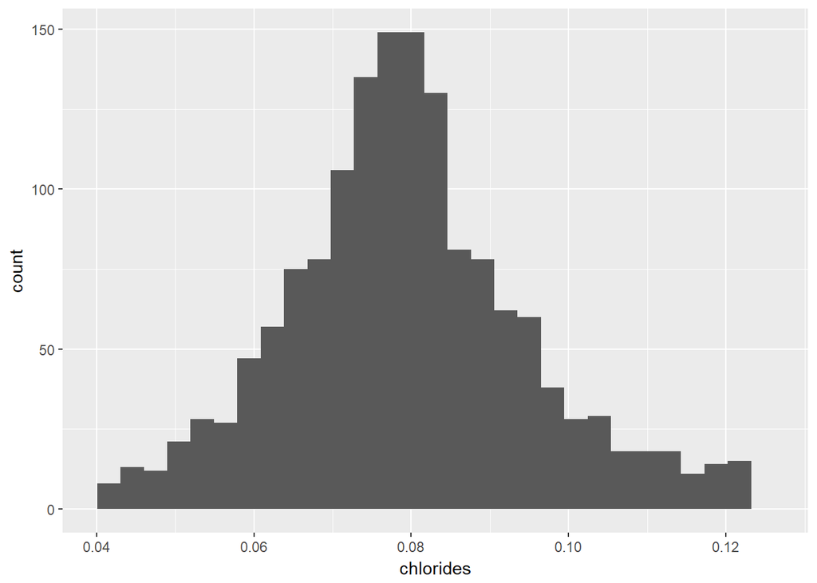

After removing outliers for chlorides, the plot looks much more normalized than the previous graphs.The verifies the fact that the outlier removal task actually worked.

### Correlation between chlorides and residual.sugar

```
##
##  Pearson's product-moment correlation
##
## data:  rw$chlorides and rw$residual.sugar
## t = 2.2257, df = 1597, p-value = 0.02617
## alternative hypothesis: true correlation is not equal to 0
## 95 percent confidence interval:
##  0.006606405 0.104346223
## sample estimates:
##        cor
## 0.05560954
```

## Questions

### What is the structure of your dataset?

```
## 'data.frame':    1599 obs. of  15 variables:
##  $ X                   : int  1 2 3 4 5 6 7 8 9 10 ...
##  $ fixed.acidity       : num  7.4 7.8 7.8 11.2 7.4 7.4 7.9 7.3 7.8 7.5 ...
##  $ volatile.acidity    : num  0.7 0.88 0.76 0.28 0.7 0.66 0.6 0.65 0.58 0.5 ...
##  $ citric.acid         : num  0 0 0.04 0.56 0 0 0.06 0 0.02 0.36 ...
##  $ residual.sugar      : num  1.9 2.6 2.3 1.9 1.9 1.8 1.6 1.2 2 6.1 ...
##  $ chlorides           : num  0.076 0.098 0.092 0.075 0.076 0.075 0.069 0.065 0.073 0.071 ...
##  $ free.sulfur.dioxide : num  11 25 15 17 11 13 15 15 9 17 ...
##  $ total.sulfur.dioxide: num  34 67 54 60 34 40 59 21 18 102 ...
##  $ density             : num  0.998 0.997 0.997 0.998 0.998 ...
##  $ pH                  : num  3.51 3.2 3.26 3.16 3.51 3.51 3.3 3.39 3.36 3.35 ...
##  $ sulphates           : num  0.56 0.68 0.65 0.58 0.56 0.56 0.46 0.47 0.57 0.8 ...
##  $ alcohol             : num  9.4 9.8 9.8 9.8 9.4 9.4 9.4 10 9.5 10.5 ...
##  $ quality             : int  5 5 5 6 5 5 5 7 7 5 ...
##  $ rating              : Ord.factor w/ 3 levels "poor"<"good"<..: 2 2 2 2 2 2 2 3 3 2 ...
##  $ total.acidity       : num  8.1 8.68 8.6 12.04 8.1 ...
```

### What is/are the main feature(s) of interest in your dataset?

My main objective is the analyze the quality of red wines. Hence red wine quality is the main feature.

### What other features in the dataset do you think will help support your

### investigation into your feature(s) of interest?

Density and pH are also normally distributed as our new variable rating. So, these two can help support our analysis.

### Did you create any new variables from existing variables in the dataset?

I created an ordered factor rating, level each variable as ‘poor’, ‘good’ and ‘best’.And, total.acidity to calculate the sum of all acids.

### Of the features you investigated, were there any unusual distributions?

### Did you perform any operations on the data to tidy, adjust, or change the form

### of the data? If so, why did you do this?

Residual.sugar and chlorides contain many outliers but after doing some operations, chlorides get into normal distribution.Citric.acid have very large number of zero values but after reading the documentation it’s fine as it found in small quantities.

## Correlation of variables against quality

```
##        fixed.acidity     volatile.acidity          citric.acid
##           0.12405165          -0.39055778           0.22637251
##       residual.sugar            chlorides  free.sulfur.dioxide
##           0.01373164          -0.12890656          -0.05065606
## total.sulfur.dioxide              density                   pH
##          -0.18510029          -0.17491923          -0.05773139
##            sulphates              alcohol        total.acidity
##           0.25139708           0.47616632           0.10375373
```

### Mean of variables for best rating

```
##        fixed.acidity     volatile.acidity          citric.acid
##           8.84700461           0.40552995           0.37649770
##       residual.sugar            chlorides  free.sulfur.dioxide
##           2.70875576           0.07591244          13.98156682
## total.sulfur.dioxide              density                   pH
##          34.88940092           0.99603028           3.28880184
##            sulphates              alcohol        total.acidity
##           0.74345622          11.51804916           9.62903226
```

The above are the mean values required for all the chemicals that compose the wine to make the wine fall into the best category.

### Median of variables for best rating

```
##        fixed.acidity     volatile.acidity          citric.acid
##              8.70000              0.37000              0.40000
##       residual.sugar            chlorides  free.sulfur.dioxide
##              2.30000              0.07300             11.00000
## total.sulfur.dioxide              density                   pH
##             27.00000              0.99572              3.27000
##            sulphates              alcohol        total.acidity
##              0.74000             11.60000              9.47000
```

## Bivariate Analysis

### Poor rating seems to have following trends:

lower fixed.acidity, higher volatile.acidity and lower citric.acid lower sulfur.dioxide and sulfates, higher pH and high density

### Good rating seems to have following trends:

low fixed.acidity and volatile.acidity higher sulfur.dioxide low pH and higher density

### Best rating seems to have following trends:

higher fixed.Acidity, lower volatile.acidity and higher citric.acid low sulfur.dioxide and higher sulfates lower pH and density

### Let’s see some relationships between some variable and total.acidity

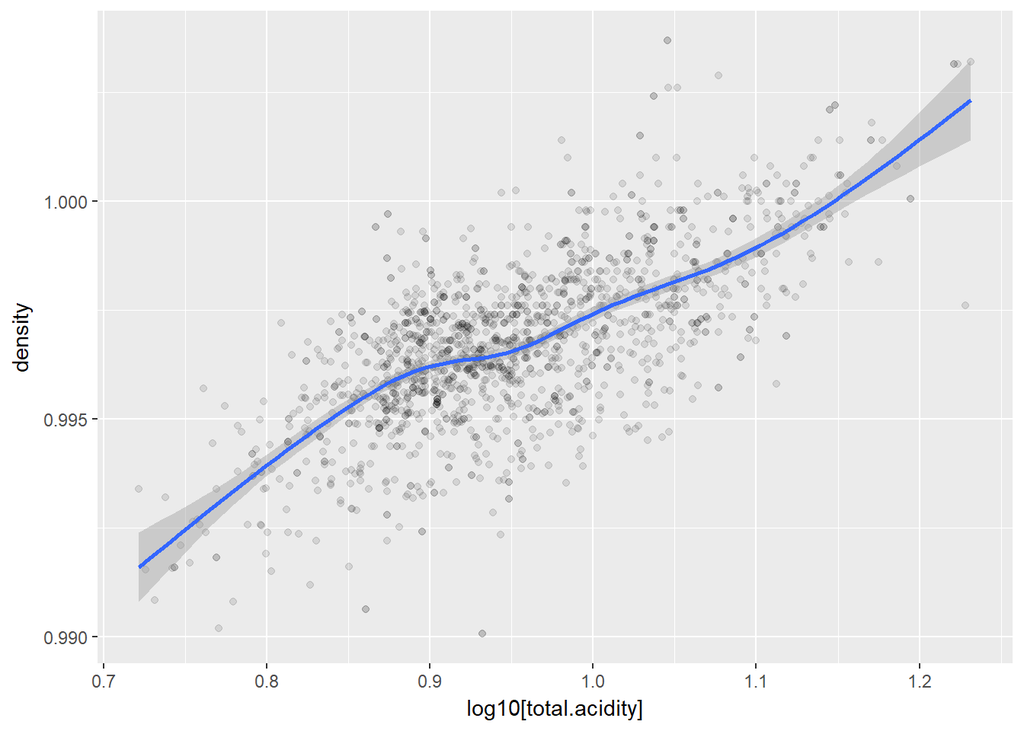

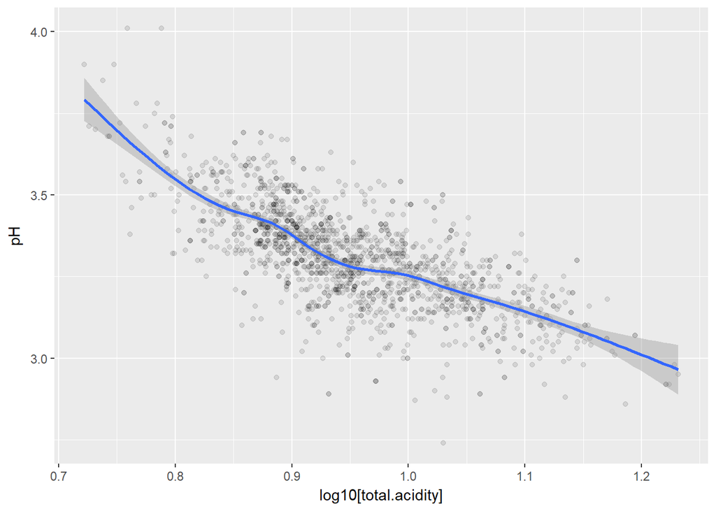

We see that there is almost a linear relationship between density and log10(total.acidity), and pH and log10(total.acidity). The plot between density and total acidity has a positive slope while that of ph vs total acidity has a negative slope.

## Multivariate Plots Section

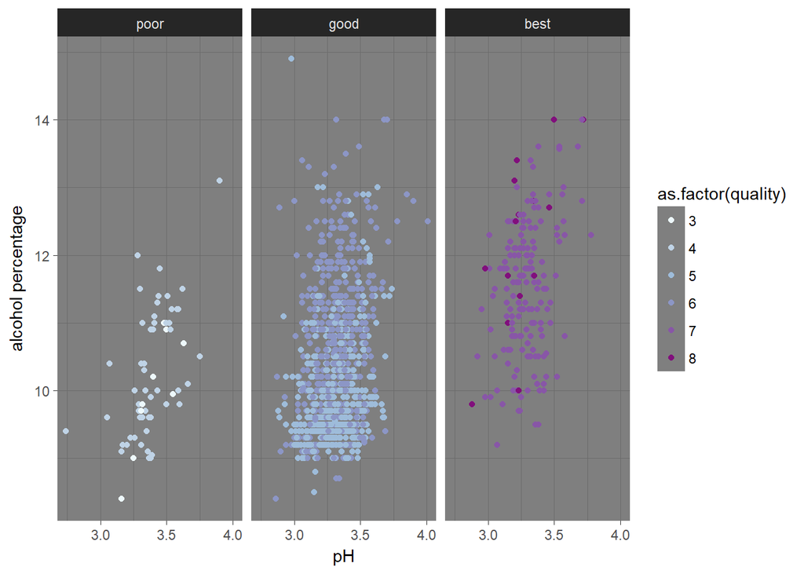

I chose to plot alcohol percentage vs pH, because, pH governs many elements in winemaking and is consequently a crucial parameter. One important effect of pH, concerns wine stability - very simple adverse organism are far less able to survive in wine that contains strong acidity as a result low pH. Majority of pH values are in the good wine category roughly between 3.0 and 4.0 quality factors.

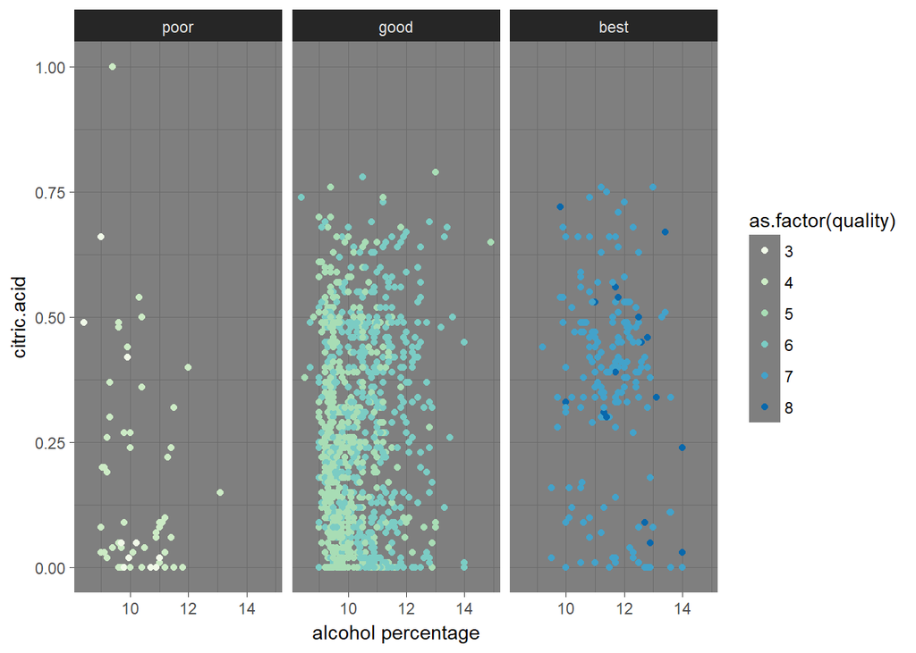

Usually citric acid content in the wine needs to be less, otherwise, the wine may become aggressively citric in nature. It is always added after alcohol fermentation as yeasts convert it into acetic acid.

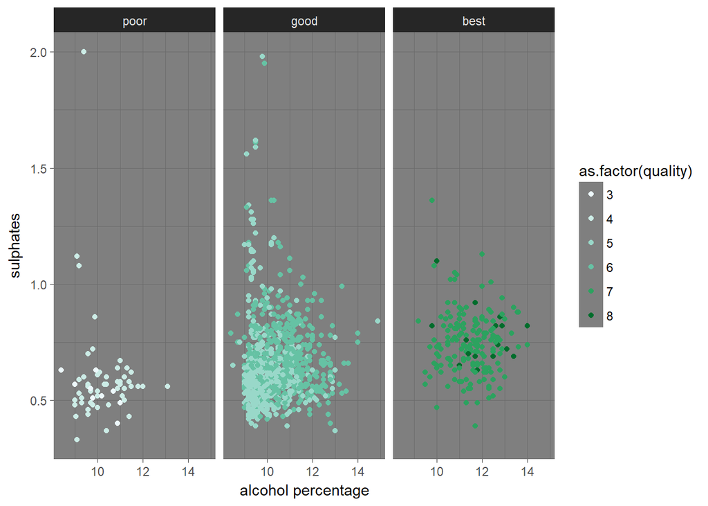

Sulphates play a very important role in the art of winemaking, due to its ability to maintain the freshness of the wine for a long duration. The plot of sulfates and alcohol % reveal that majority of the data points are indeed concentrated for the good category wine. The alcohol percentage has a quality factor between 9 and 13 for the good category wine, which is the most populous.

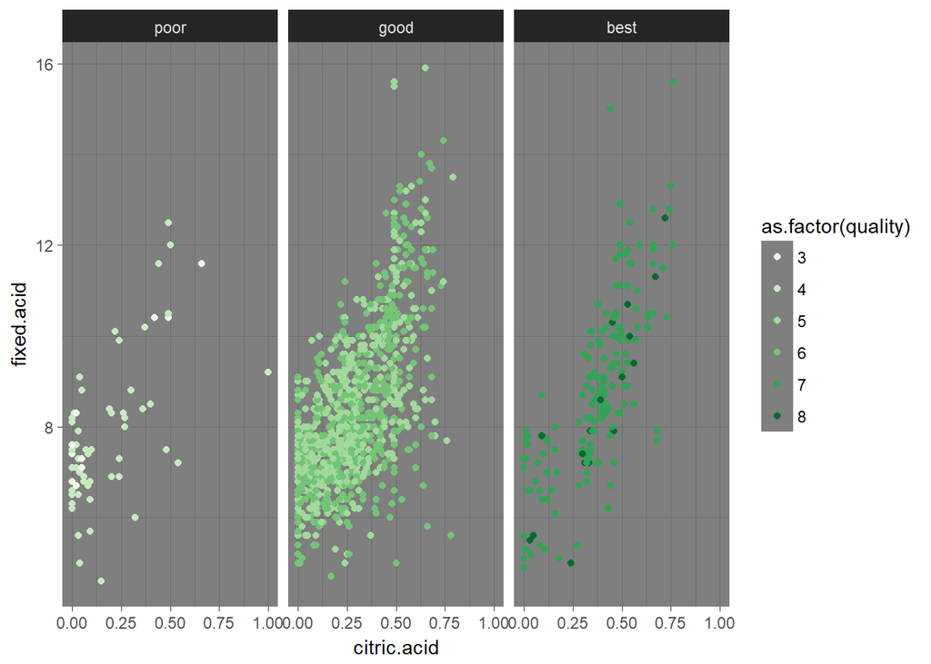

Since, by convention total.acidity is of two types, volatile and fixed acids. I wanted to visualize the relations between fixed and citric acids. From the plot it is evident that even at 0 quality factor for citric acids te fixed acids are the majority in number for the good category wines.

## Final Plots and Summary

### Plot One: Effect of alcohol on wine quality

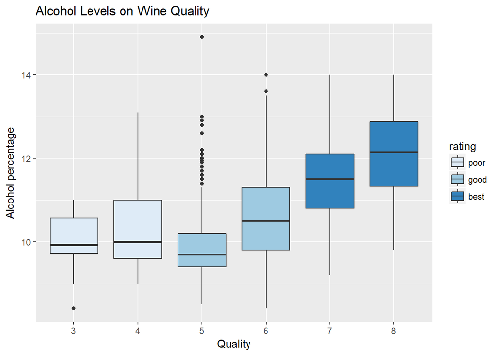

### Description One

We can observe from the plot that, since alcohol is highly correlated with quality, it is better to see its pattern with varying rating.We can observe from the plot that, higher the percentage of alcohol better is the wine quality.

### Plot Two: Effect of acids on wine quality

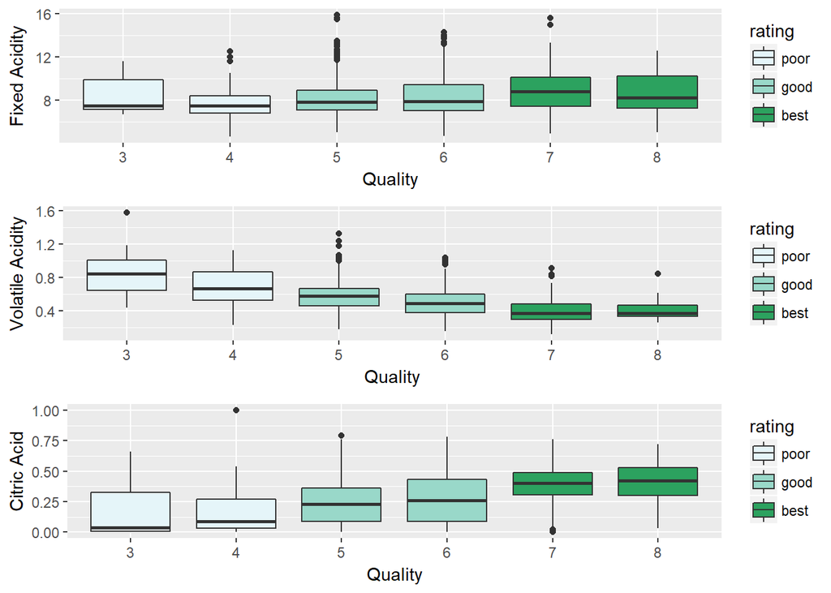

### Plot Three: poor vs best wine

[figure not shown]